# project2

2025-10-22

Introduction:

Loss-of-function mutations in the tyrosine kinase 2 gene has been associated with an incresed risk of type-1 diabetes Wildtype tyrosine kinase 2 and knockout version of a genome were studied to observe the impact this gene has on the immune system response and bodily function overall. Knockout testing is a common approach in bioinformatics to study the impact of mis/non-function of a gene, through intentionally removing this gene from samples.

Methods: Three paired end control reads and three paired end sample reads of RNA were collected and ran through FastQC v0.12.1 to observe the quality of these samples.

A reference genome from NCBI was indexed and aligned to the sample genomes with STAR 2.7.10. The count of expressed genes was obtained through VERSE 0.1.6 which, had an output that was manipulated for further analysis using Python 3.12.2. Differential expressoion analysis was performed on these samples using DESEQ2 1.40.0 and R 4.3.1.

[output not shown]

```r
library(readr)
library(tidyverse)
BiocManager::install("fgsea")
cts <- as.matrix(read.csv("results/counts_matrix.csv", row.names="gene"))
```

```r
before <- nrow(cts)
filter_cts <- cts[rowSums(cts) >= 10, , drop = FALSE]
after <- nrow(filter_cts)
```

```r
print(before)
```

```
## [1] 63241
```

```r
print(after)
```

```
## [1] 27723
```

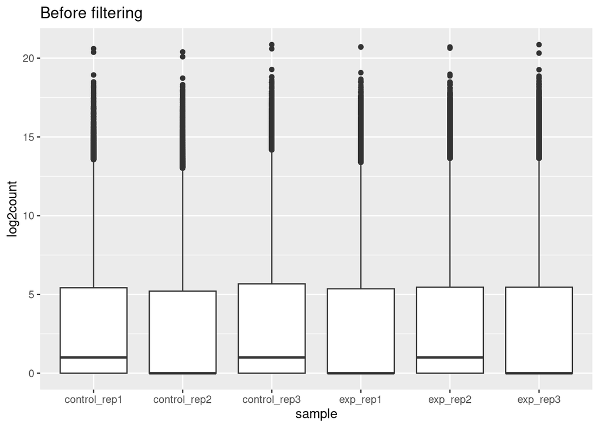

```r
df_before<- as.data.frame(cts)
df_before$gene <-rownames(df_before)
df_before_long <-pivot_longer(df_before, cols = -gene,names_to = "sample", values_to ="count") %>%
  mutate(log2count = log2(count + 1))

df_after <-as.data.frame(filter_cts)
df_after$gene<- rownames(df_after)
df_after_long <-pivot_longer(df_after, cols = -gene, names_to = "sample", values_to ="count") %>%
  mutate(log2count = log2(count + 1))

ggplot(df_before_long, aes(sample, log2count)) + geom_boxplot() + ggtitle("Before filtering")
```

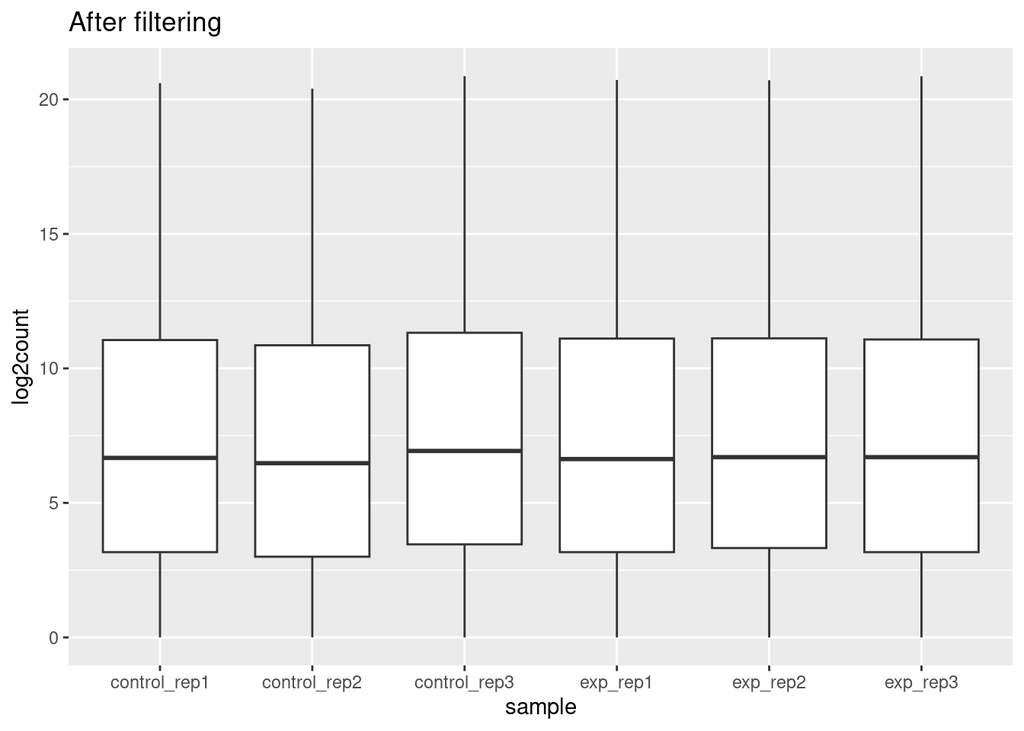

```r
ggplot(df_after_long,aes(sample, log2count))+ geom_boxplot()+ ggtitle("After filtering")
```

Gene counts with a frequency less than 10 across all 6 samples were filtered out of this data, which is a common RNA-seq filtering strategy since these counts are too small to reveal any information of value. This filtering strategy took the total gene size of 63241 down to 27723, leaving only genes with counts greater than 10. The box plots demonstrate that the filtering technique was successful, with the filtered sample points having a much cleaner distribution compared to the raw sample points that included many genes less than 10 counts total. This was performed using log2count to avoid the large gene counts from skewing the data and spreading out the smaller gene counts more, overall producing a cleaner distrubition represented in the box plots.

```r
samples <- c('control_rep1','exp_rep3', 'control_rep2',
             'exp_rep1',  'control_rep3','exp_rep2')

condition <- factor(c('control', 'exp', 'control','exp', 'control','exp' ))

colData <- data.frame(row.names = samples, condition = condition)
```

```r
dds<- DESeqDataSetFromMatrix(countData = filter_cts,
                              colData = colData, design = ~ condition)
```

```r
dds <- DESeq(dds)
res <- results(dds, contrast = c("condition", "exp", "control"))

res_order <- res[order(res$padj), ]
deseq2_res <- as_tibble(res_order, rownames = 'gene')
```

```r
id2name <- read_tsv("results/idgenename.txt", col_names = c("gene", "symbol"))
deseq2_res <- deseq2_res %>% left_join(id2name, by = "gene")
nrow(deseq2_res)
```

```
## [1] 27723
```

```r
pos_res <- deseq2_res %>%
  filter(padj < 2.4e-12
) %>%
  pull(symbol)

length(pos_res)
```

```
## [1] 45
```

```r
summary(deseq2_res$padj)
```

```
##    Min. 1st Qu.  Median    Mean 3rd Qu.    Max.    NA's
##   0.000   0.663   0.915   0.766   0.978   1.000    6988
```

```r
head(deseq2_res[order(deseq2_res$padj), ], 10)
```

```
## # A tibble: 10 × 8
##    gene           baseMean log2FoldChange lfcSE  stat    pvalue      padj symbol
##    <chr>             <dbl>          <dbl> <dbl> <dbl>     <dbl>     <dbl> <chr>
##  1 ENSG000001298…   10668.          -8.77 0.146 -60.0 0         0         RPS4Y1
##  2 ENSG000002895…     730.           3.70 0.128  28.8 5.80e-183 6.01e-179 ENSG0…
##  3 ENSG000001084…     604.          -4.16 0.145 -28.7 9.07e-182 6.27e-178 PNPO
##  4 ENSG000002538…     496.           4.48 0.196  22.8 3.77e-115 1.96e-111 PCDHG…
##  5 ENSG000002506…     524.          -2.42 0.120 -20.2 2.29e- 90 9.49e- 87 YPEL3…
##  6 ENSG000002511…    1300.          -1.72 0.102 -16.8 4.89e- 63 1.69e- 59 LINC0…
##  7 ENSG000002894…     383.          -2.13 0.145 -14.7 5.48e- 49 1.62e- 45 ENSG0…
##  8 ENSG000002863…     906.          -1.72 0.117 -14.7 1.33e- 48 3.45e- 45 ENSG0…
##  9 ENSG000002829…     121.           3.76 0.265  14.2 1.45e- 45 3.33e- 42 ENSG0…
## 10 ENSG000002910…     153.           2.88 0.206  14.0 2.87e- 44 5.95e- 41 SVIL-…
```

```r
write.table(pos_res, file = "genesfile.txt", col.names = FALSE, row.names = FALSE, quote = FALSE)
```

```r
library(pheatmap)

vsd <- vst(dds, blind=FALSE)
pcaData <- plotPCA(vsd, intgroup = "condition", returnData = TRUE)
```

```
## using ntop=500 top features by variance
```

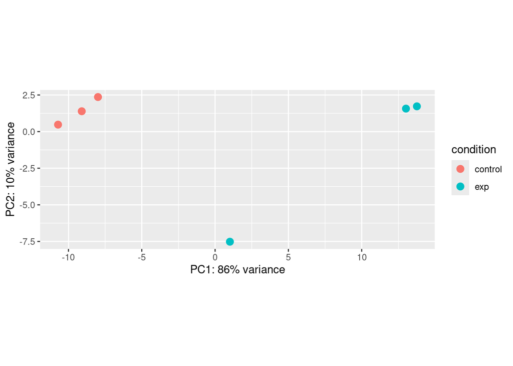

```r
percentVar <- round(100 * attr(pcaData, "percentVar"))

ggplot(pcaData, aes(PC1, PC2, color=condition)) +
  geom_point(size=3) +
  xlab(paste0("PC1: ",percentVar[1],"% variance")) +
  ylab(paste0("PC2: ",percentVar[2],"% variance")) +
  coord_fixed()
```

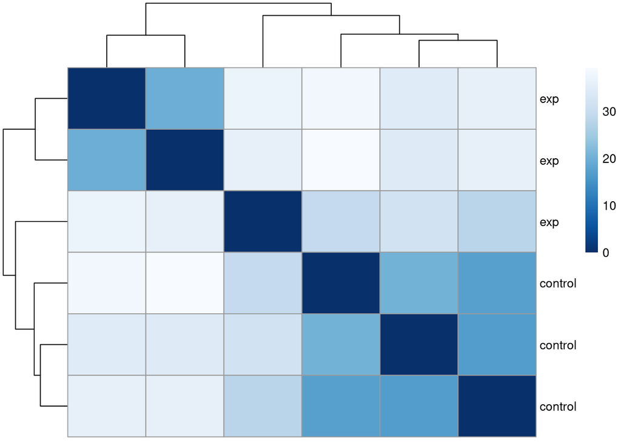

```r
sampleDists <- dist(t(assay(vsd)))
library("RColorBrewer")
sampleDistMatrix <- as.matrix(sampleDists)
rownames(sampleDistMatrix) <- paste(vsd$condition, sep="-")
colnames(sampleDistMatrix) <- NULL
colors <- colorRampPalette( rev(brewer.pal(9, "Blues")) )(255)
pheatmap(sampleDistMatrix,
         clustering_distance_rows=sampleDists,
         clustering_distance_cols=sampleDists,
         col=colors)
```

The PC1 vs PC2 plot demonstrates Control groups grouping together with a similar variance, while two of the experimental samples being grouped together, and the third experimental sample seemingly being an outlier.

The heatmap demonstrates a similar pattern to the PCA plot, with two of the experimental groups clustering together and having a similar distance, an outlier experimental group, and then the control groups all clustering together in dark shades.

Given that these two analyses and their plots demonstrate similar patterns, and these patterns have mostly distinct control and experimental groups (with the exception of one experimental group outlier), this experiment seems to have been a success and has determined nificant differentiated genes when samples were treated vs. the control samples.

```r
library(fgsea)

deseq2_res_ordered <- deseq2_res %>%
  drop_na(log2FoldChange, symbol) %>%
  distinct(symbol, .keep_all = TRUE) %>%
  arrange(desc(log2FoldChange))

rnk_list <- setNames(deseq2_res_ordered$log2FoldChange, deseq2_res_ordered$symbol)


pathways <- gmtPathways("results/c2.all.v2025.1.Hs.symbols.gmt.txt")
fgseaRes <- fgsea(pathways, rnk_list, minSize=15, maxSize=500)
```

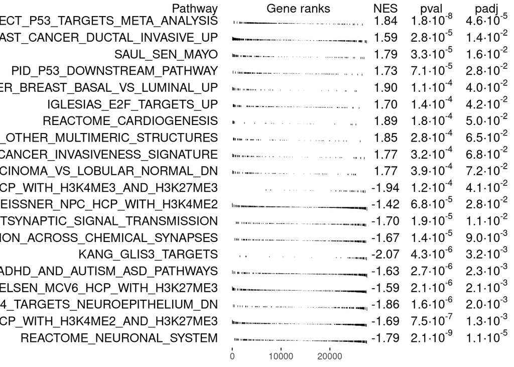

```r
topPathwaysUp <- fgseaRes[ES > 0][head(order(pval), n=10), pathway]
topPathwaysDown <- fgseaRes[ES < 0][head(order(pval), n=10), pathway]
topPathways <- c(topPathwaysUp, rev(topPathwaysDown))
plotGseaTable(pathways[topPathways], rnk_list, fgseaRes,
              gseaParam=0.5)
```

The fgsea analysis demonstrates the most downregulated and most upregulated pathways with regards to the nificant differentiated genes. The output from this run appears to demonstrate that various pathways related to cancer are upregulated in the treatment compared to the control group, and various neural system pathways are downregulated. The upregulated pathways include p53 downstream pathway, cancer invasiveness, and metastatic breast cancer, while the downregulated include reactome neuronal system, ADHD and autism pathways, and synpatic nal transmission.

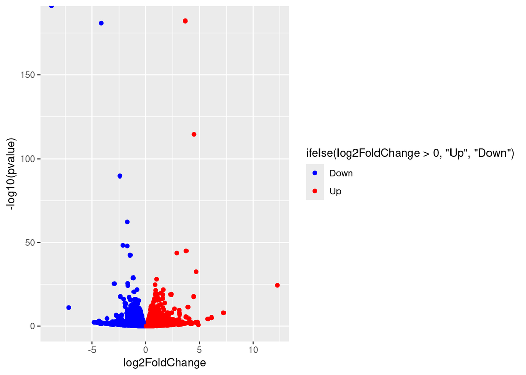

```r
ggplot(deseq2_res, aes(log2FoldChange, -log10(pvalue),color =ifelse(log2FoldChange >0, "Up","Down"))) +
  geom_point()+
  scale_color_manual(values = c("Down" = "blue", "Up" = "red"))
```

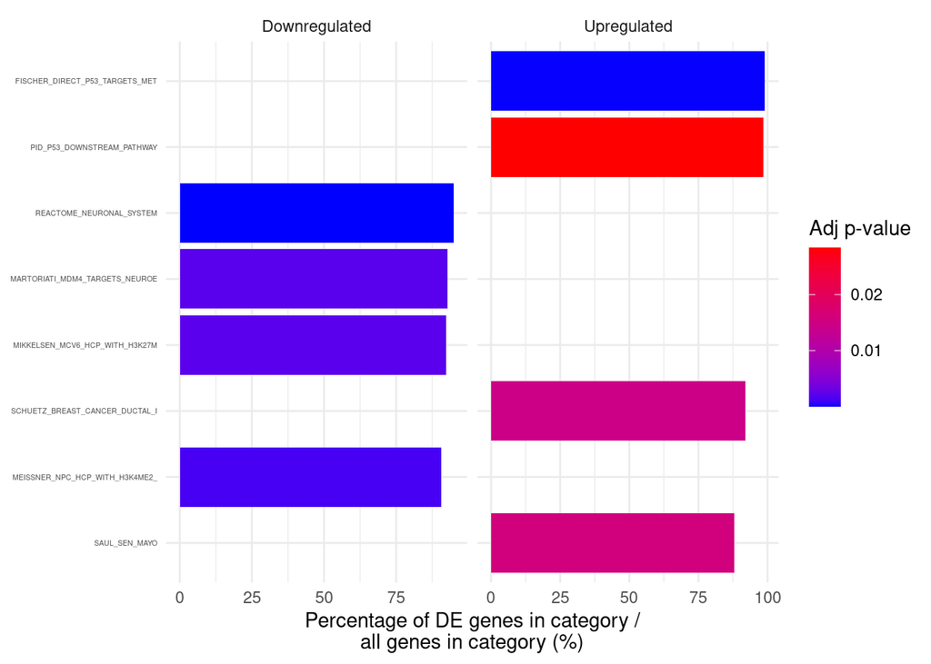

```r
library(stringr)

topPathwaysf3 <- c(topPathwaysUp[1:4], topPathwaysDown[1:4])

plot_df <-fgseaRes %>%
  filter(pathway %in% topPathwaysf3) %>%
  mutate(direction= ifelse(ES > 0, "Upregulated", "Downregulated")) %>%
  rowwise() %>%
  mutate(
    pct_DE =(length(intersect(pathways[[pathway]],deseq2_res_ordered$symbol)) / length(pathways[[pathway]])) *100,
    pathway_short = str_sub(pathway, 1, 30)
  ) %>%
  ungroup()

ggplot(plot_df, aes(x =reorder(pathway_short, pct_DE), y =pct_DE,fill = padj)) +
  geom_col() +
  facet_wrap(~direction,scales="free_x") +
  coord_flip()+
  scale_fill_gradient(low = "blue", high = "red") +
  labs(x =NULL,y = "Percentage of DE genes in category /
all genes in category (%)",fill ="Adj p-value") +
  theme_minimal()+
  theme(axis.text.y = element_text(size = 4))
```

```r
testsig<- 2.4e-12

sig_list <- deseq2_res %>%
  filter(!is.na(padj) & padj <testsig)

up_sigs <- sig_list %>% filter(log2FoldChange > 0) %>% nrow()
down_sigs <-sig_list %>% filter(log2FoldChange < 0) %>% nrow()

cat("Up-regulated:", up_sigs,"\n")
```

```
## Up-regulated: 24
```

```r
cat("Down-regulated:", down_sigs,"\n")
```

```
## Down-regulated: 21
```

The provided paper observed 319 upregulated and 412 downregulated genes. With my runs, I had only observed 24 upregulated and 21 downregulated genes at a significant threshold of padj=2.4E-12.